# Risk Factor Analysis

## Outcome Variable

**Outcome Variable:** stunted

## Predictor Variables

**Intervention Variable:** mage

**Adjustment Set:**

- arm
- meducyrs
- feducyrs
- W_mhtcm
- single
- delta_meducyrs
- delta_feducyrs
- delta_W_mhtcm
- delta_single

## Stratifying Variables

The analysis was stratified on these variable(s):

- agecat
- studyid
- country

## Data Summary

| agecat | studyid | country | mage | stunted | n_cell | n |
| --- | --- | --- | --- | --- | --- | --- |
| Birth | ki0047075b-MAL-ED | BANGLADESH | [20-30) | 0 | 147 | 257 |
| Birth | ki0047075b-MAL-ED | BANGLADESH | [20-30) | 1 | 29 | 257 |
| Birth | ki0047075b-MAL-ED | BANGLADESH | <20 | 0 | 27 | 257 |
| Birth | ki0047075b-MAL-ED | BANGLADESH | <20 | 1 | 9 | 257 |
| Birth | ki0047075b-MAL-ED | BANGLADESH | >=30 | 0 | 36 | 257 |
| Birth | ki0047075b-MAL-ED | BANGLADESH | >=30 | 1 | 9 | 257 |
| Birth | ki0047075b-MAL-ED | BRAZIL | [20-30) | 0 | 101 | 191 |
| Birth | ki0047075b-MAL-ED | BRAZIL | [20-30) | 1 | 16 | 191 |
| Birth | ki0047075b-MAL-ED | BRAZIL | <20 | 0 | 32 | 191 |
| Birth | ki0047075b-MAL-ED | BRAZIL | <20 | 1 | 2 | 191 |
| Birth | ki0047075b-MAL-ED | BRAZIL | >=30 | 0 | 37 | 191 |
| Birth | ki0047075b-MAL-ED | BRAZIL | >=30 | 1 | 3 | 191 |
| Birth | ki0047075b-MAL-ED | INDIA | [20-30) | 0 | 139 | 205 |
| Birth | ki0047075b-MAL-ED | INDIA | [20-30) | 1 | 26 | 205 |
| Birth | ki0047075b-MAL-ED | INDIA | <20 | 0 | 20 | 205 |
| Birth | ki0047075b-MAL-ED | INDIA | <20 | 1 | 5 | 205 |
| Birth | ki0047075b-MAL-ED | INDIA | >=30 | 0 | 14 | 205 |
| Birth | ki0047075b-MAL-ED | INDIA | >=30 | 1 | 1 | 205 |
| Birth | ki0047075b-MAL-ED | NEPAL | [20-30) | 0 | 120 | 173 |
| Birth | ki0047075b-MAL-ED | NEPAL | [20-30) | 1 | 12 | 173 |
| Birth | ki0047075b-MAL-ED | NEPAL | <20 | 0 | 3 | 173 |
| Birth | ki0047075b-MAL-ED | NEPAL | <20 | 1 | 2 | 173 |
| Birth | ki0047075b-MAL-ED | NEPAL | >=30 | 0 | 32 | 173 |
| Birth | ki0047075b-MAL-ED | NEPAL | >=30 | 1 | 4 | 173 |
| Birth | ki0047075b-MAL-ED | PERU | [20-30) | 0 | 133 | 287 |
| Birth | ki0047075b-MAL-ED | PERU | [20-30) | 1 | 12 | 287 |
| Birth | ki0047075b-MAL-ED | PERU | <20 | 0 | 63 | 287 |
| Birth | ki0047075b-MAL-ED | PERU | <20 | 1 | 14 | 287 |
| Birth | ki0047075b-MAL-ED | PERU | >=30 | 0 | 57 | 287 |
| Birth | ki0047075b-MAL-ED | PERU | >=30 | 1 | 8 | 287 |

[output cut: 378 more lines]

The following strata were considered:

- agecat: 24 months, studyid: ki0047075b-MAL-ED, country: BANGLADESH
- agecat: 24 months, studyid: ki0047075b-MAL-ED, country: BRAZIL
- agecat: 24 months, studyid: ki0047075b-MAL-ED, country: INDIA
- agecat: 24 months, studyid: ki0047075b-MAL-ED, country: NEPAL
- agecat: 24 months, studyid: ki0047075b-MAL-ED, country: PERU
- agecat: 24 months, studyid: ki0047075b-MAL-ED, country: SOUTH AFRICA
- agecat: 24 months, studyid: ki0047075b-MAL-ED, country: TANZANIA, UNITED REPUBLIC OF
- agecat: 24 months, studyid: ki1000108-CMC-V-BCS-2002, country: INDIA
- agecat: 24 months, studyid: ki1000108-IRC, country: INDIA
- agecat: 24 months, studyid: ki1017093-NIH-Birth, country: BANGLADESH
- agecat: 24 months, studyid: ki1017093b-PROVIDE, country: BANGLADESH
- agecat: 24 months, studyid: ki1017093c-NIH-Crypto, country: BANGLADESH
- agecat: 24 months, studyid: ki1066203-TanzaniaChild2, country: TANZANIA, UNITED REPUBLIC OF
- agecat: 24 months, studyid: ki1101329-Keneba, country: GAMBIA
- agecat: 24 months, studyid: ki1113344-GMS-Nepal, country: NEPAL
- agecat: 24 months, studyid: ki1119695-PROBIT, country: BELARUS
- agecat: 24 months, studyid: ki1126311-ZVITAMBO, country: ZIMBABWE
- agecat: 24 months, studyid: ki1135781-COHORTS, country: GUATEMALA
- agecat: 24 months, studyid: ki1135781-COHORTS, country: INDIA
- agecat: 24 months, studyid: ki1135781-COHORTS, country: PHILIPPINES
- agecat: 24 months, studyid: ki1148112-LCNI-5, country: MALAWI
- agecat: 24 months, studyid: kiGH5241-JiVitA-3, country: BANGLADESH
- agecat: 6 months, studyid: ki0047075b-MAL-ED, country: BANGLADESH
- agecat: 6 months, studyid: ki0047075b-MAL-ED, country: BRAZIL
- agecat: 6 months, studyid: ki0047075b-MAL-ED, country: INDIA
- agecat: 6 months, studyid: ki0047075b-MAL-ED, country: NEPAL
- agecat: 6 months, studyid: ki0047075b-MAL-ED, country: PERU
- agecat: 6 months, studyid: ki0047075b-MAL-ED, country: SOUTH AFRICA
- agecat: 6 months, studyid: ki0047075b-MAL-ED, country: TANZANIA, UNITED REPUBLIC OF
- agecat: 6 months, studyid: ki1000108-CMC-V-BCS-2002, country: INDIA
- agecat: 6 months, studyid: ki1000108-IRC, country: INDIA
- agecat: 6 months, studyid: ki1000109-EE, country: PAKISTAN
- agecat: 6 months, studyid: ki1000304b-SAS-CompFeed, country: INDIA
- agecat: 6 months, studyid: ki1000304b-SAS-FoodSuppl, country: INDIA
- agecat: 6 months, studyid: ki1017093-NIH-Birth, country: BANGLADESH
- agecat: 6 months, studyid: ki1017093b-PROVIDE, country: BANGLADESH
- agecat: 6 months, studyid: ki1017093c-NIH-Crypto, country: BANGLADESH
- agecat: 6 months, studyid: ki1066203-TanzaniaChild2, country: TANZANIA, UNITED REPUBLIC OF
- agecat: 6 months, studyid: ki1101329-Keneba, country: GAMBIA
- agecat: 6 months, studyid: ki1112895-Guatemala BSC, country: GUATEMALA
- agecat: 6 months, studyid: ki1113344-GMS-Nepal, country: NEPAL
- agecat: 6 months, studyid: ki1119695-PROBIT, country: BELARUS
- agecat: 6 months, studyid: ki1126311-ZVITAMBO, country: ZIMBABWE
- agecat: 6 months, studyid: ki1135781-COHORTS, country: GUATEMALA
- agecat: 6 months, studyid: ki1135781-COHORTS, country: INDIA
- agecat: 6 months, studyid: ki1135781-COHORTS, country: PHILIPPINES
- agecat: 6 months, studyid: ki1148112-LCNI-5, country: MALAWI
- agecat: 6 months, studyid: kiGH5241-JiVitA-3, country: BANGLADESH
- agecat: Birth, studyid: ki0047075b-MAL-ED, country: BANGLADESH
- agecat: Birth, studyid: ki0047075b-MAL-ED, country: BRAZIL
- agecat: Birth, studyid: ki0047075b-MAL-ED, country: INDIA
- agecat: Birth, studyid: ki0047075b-MAL-ED, country: NEPAL
- agecat: Birth, studyid: ki0047075b-MAL-ED, country: PERU
- agecat: Birth, studyid: ki0047075b-MAL-ED, country: SOUTH AFRICA
- agecat: Birth, studyid: ki0047075b-MAL-ED, country: TANZANIA, UNITED REPUBLIC OF
- agecat: Birth, studyid: ki1000108-CMC-V-BCS-2002, country: INDIA
- agecat: Birth, studyid: ki1000108-IRC, country: INDIA
- agecat: Birth, studyid: ki1000109-EE, country: PAKISTAN
- agecat: Birth, studyid: ki1000304b-SAS-CompFeed, country: INDIA
- agecat: Birth, studyid: ki1017093-NIH-Birth, country: BANGLADESH
- agecat: Birth, studyid: ki1017093c-NIH-Crypto, country: BANGLADESH
- agecat: Birth, studyid: ki1101329-Keneba, country: GAMBIA
- agecat: Birth, studyid: ki1119695-PROBIT, country: BELARUS
- agecat: Birth, studyid: ki1126311-ZVITAMBO, country: ZIMBABWE
- agecat: Birth, studyid: ki1135781-COHORTS, country: GUATEMALA
- agecat: Birth, studyid: ki1135781-COHORTS, country: INDIA
- agecat: Birth, studyid: ki1135781-COHORTS, country: PHILIPPINES
- agecat: Birth, studyid: kiGH5241-JiVitA-3, country: BANGLADESH

### Dropped Strata

Some strata were dropped due to rare outcomes:

- agecat: Birth, studyid: ki0047075b-MAL-ED, country: BRAZIL
- agecat: Birth, studyid: ki0047075b-MAL-ED, country: INDIA
- agecat: Birth, studyid: ki0047075b-MAL-ED, country: NEPAL
- agecat: Birth, studyid: ki0047075b-MAL-ED, country: TANZANIA, UNITED REPUBLIC OF
- agecat: Birth, studyid: ki1000108-CMC-V-BCS-2002, country: INDIA
- agecat: Birth, studyid: ki1000108-IRC, country: INDIA
- agecat: Birth, studyid: ki1000109-EE, country: PAKISTAN
- agecat: Birth, studyid: ki1000304b-SAS-CompFeed, country: INDIA
- agecat: Birth, studyid: ki1017093-NIH-Birth, country: BANGLADESH
- agecat: Birth, studyid: ki1017093c-NIH-Crypto, country: BANGLADESH
- agecat: Birth, studyid: ki1119695-PROBIT, country: BELARUS
- agecat: 6 months, studyid: ki0047075b-MAL-ED, country: BRAZIL
- agecat: 6 months, studyid: ki0047075b-MAL-ED, country: INDIA
- agecat: 6 months, studyid: ki0047075b-MAL-ED, country: NEPAL
- agecat: 6 months, studyid: ki0047075b-MAL-ED, country: TANZANIA, UNITED REPUBLIC OF
- agecat: 6 months, studyid: ki1000109-EE, country: PAKISTAN
- agecat: 24 months, studyid: ki0047075b-MAL-ED, country: BRAZIL
- agecat: 24 months, studyid: ki0047075b-MAL-ED, country: INDIA
- agecat: 24 months, studyid: ki0047075b-MAL-ED, country: NEPAL
- agecat: 24 months, studyid: ki0047075b-MAL-ED, country: TANZANIA, UNITED REPUBLIC OF
- agecat: 24 months, studyid: ki1066203-TanzaniaChild2, country: TANZANIA, UNITED REPUBLIC OF

## Methods Detail

We’re interested in the causal parameters $E[Y_a]$ for all values of $a \in \mathcal{A}$. These parameters represent the mean outcome if, possibly contrary to fact, we intervened to set all units to have $A=a$. Under the randomization and positivity assumptions, these are identified by the statistical parameters $\psi_a=E_W[E_{Y|A,W}(Y|A=a,W)]$. In addition, we’re interested in the mean of $Y$, $E[Y]$ under no intervention (the observed mean). We will estimate these parameters by using SuperLearner to fit the relevant likelihood factors – $E_{Y|A,W}(Y|A=a,W)$ and $p(A=a|W)$, and then updating our likelihood fit using a joint TMLE.

For unadjusted analyses ($W=\{\}$), initial likelihoods were estimated using Lrnr_glm to estimate the simple $E(Y|A)$ and Lrnr_mean to estimate $p(A)$. For adjusted analyses, a small library containing Lrnr_glmnet, Lrnr_xgboost, and Lrnr_mean was used.

Having estimated these parameters, we will then use the delta method to estimate relative risks and attributable risks relative to a prespecified baseline level of $A$.

# Results Detail

## Results Plots

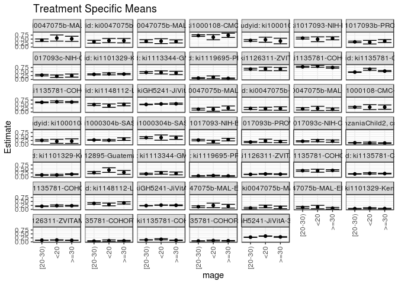

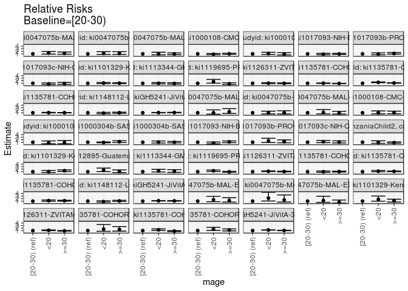

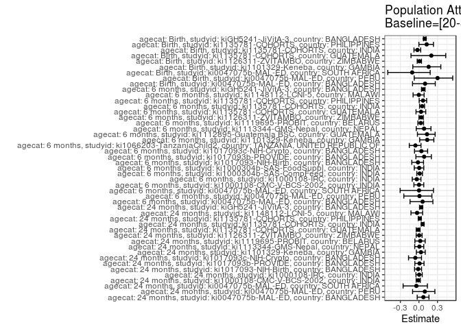

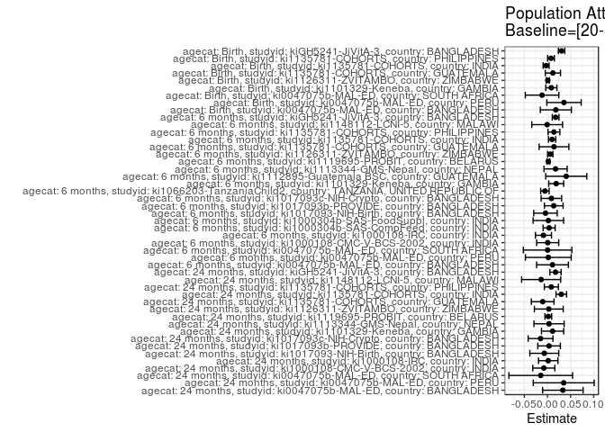

## Results Table

### Parameter: TSM

| agecat | studyid | country | intervention_level | baseline_level | estimate | ci_lower | ci_upper |
| --- | --- | --- | --- | --- | --- | --- | --- |
| Birth | ki0047075b-MAL-ED | BANGLADESH | [20-30) | NA | 0.1647727 | 0.1098587 | 0.2196868 |
| Birth | ki0047075b-MAL-ED | BANGLADESH | <20 | NA | 0.2500000 | 0.1082758 | 0.3917242 |
| Birth | ki0047075b-MAL-ED | BANGLADESH | >=30 | NA | 0.2000000 | 0.0829023 | 0.3170977 |
| Birth | ki0047075b-MAL-ED | PERU | [20-30) | NA | 0.0827586 | 0.0378354 | 0.1276818 |
| Birth | ki0047075b-MAL-ED | PERU | <20 | NA | 0.1818182 | 0.0955195 | 0.2681169 |
| Birth | ki0047075b-MAL-ED | PERU | >=30 | NA | 0.1230769 | 0.0430717 | 0.2030822 |
| Birth | ki0047075b-MAL-ED | SOUTH AFRICA | [20-30) | NA | 0.1185185 | 0.0638910 | 0.1731460 |
| Birth | ki0047075b-MAL-ED | SOUTH AFRICA | <20 | NA | 0.1463415 | 0.0379457 | 0.2547372 |
| Birth | ki0047075b-MAL-ED | SOUTH AFRICA | >=30 | NA | 0.0697674 | 0.0158224 | 0.1237125 |
| Birth | ki1101329-Keneba | GAMBIA | [20-30) | NA | 0.0448467 | 0.0296053 | 0.0600880 |
| Birth | ki1101329-Keneba | GAMBIA | <20 | NA | 0.0770799 | 0.0420144 | 0.1121454 |
| Birth | ki1101329-Keneba | GAMBIA | >=30 | NA | 0.0484079 | 0.0303134 | 0.0665024 |
| Birth | ki1126311-ZVITAMBO | ZIMBABWE | [20-30) | NA | 0.1026546 | 0.0964648 | 0.1088445 |
| Birth | ki1126311-ZVITAMBO | ZIMBABWE | <20 | NA | 0.1149340 | 0.1014743 | 0.1283937 |
| Birth | ki1126311-ZVITAMBO | ZIMBABWE | >=30 | NA | 0.0941986 | 0.0822938 | 0.1061034 |
| Birth | ki1135781-COHORTS | GUATEMALA | [20-30) | NA | 0.0469136 | 0.0263077 | 0.0675195 |
| Birth | ki1135781-COHORTS | GUATEMALA | <20 | NA | 0.0743802 | 0.0276007 | 0.1211596 |
| Birth | ki1135781-COHORTS | GUATEMALA | >=30 | NA | 0.0674847 | 0.0402373 | 0.0947320 |
| Birth | ki1135781-COHORTS | INDIA | [20-30) | NA | 0.1212348 | 0.1098136 | 0.1326560 |
| Birth | ki1135781-COHORTS | INDIA | <20 | NA | 0.1591399 | 0.1216563 | 0.1966235 |
| Birth | ki1135781-COHORTS | INDIA | >=30 | NA | 0.0981263 | 0.0809338 | 0.1153188 |
| Birth | ki1135781-COHORTS | PHILIPPINES | [20-30) | NA | 0.0536521 | 0.0432409 | 0.0640633 |
| Birth | ki1135781-COHORTS | PHILIPPINES | <20 | NA | 0.0840841 | 0.0558995 | 0.1122687 |
| Birth | ki1135781-COHORTS | PHILIPPINES | >=30 | NA | 0.0656653 | 0.0490776 | 0.0822529 |
| Birth | kiGH5241-JiVitA-3 | BANGLADESH | [20-30) | NA | 0.2925671 | 0.2822387 | 0.3028955 |
| Birth | kiGH5241-JiVitA-3 | BANGLADESH | <20 | NA | 0.3615598 | 0.3505320 | 0.3725876 |
| Birth | kiGH5241-JiVitA-3 | BANGLADESH | >=30 | NA | 0.3083051 | 0.2861870 | 0.3304232 |
| 6 months | ki0047075b-MAL-ED | BANGLADESH | [20-30) | NA | 0.1757576 | 0.1175615 | 0.2339536 |
| 6 months | ki0047075b-MAL-ED | BANGLADESH | <20 | NA | 0.1714286 | 0.0463095 | 0.2965477 |
| 6 months | ki0047075b-MAL-ED | BANGLADESH | >=30 | NA | 0.2439024 | 0.1121811 | 0.3756238 |

[output cut: 111 more lines]

### Parameter: E(Y)

| agecat | studyid | country | intervention_level | baseline_level | estimate | ci_lower | ci_upper |
| --- | --- | --- | --- | --- | --- | --- | --- |
| Birth | ki0047075b-MAL-ED | BANGLADESH | NA | NA | 0.1828794 | 0.1355257 | 0.2302330 |
| Birth | ki0047075b-MAL-ED | PERU | NA | NA | 0.1184669 | 0.0810142 | 0.1559196 |
| Birth | ki0047075b-MAL-ED | SOUTH AFRICA | NA | NA | 0.1068702 | 0.0693890 | 0.1443514 |
| Birth | ki1101329-Keneba | GAMBIA | NA | NA | 0.0532122 | 0.0420018 | 0.0644226 |
| Birth | ki1126311-ZVITAMBO | ZIMBABWE | NA | NA | 0.1034083 | 0.0983260 | 0.1084905 |
| Birth | ki1135781-COHORTS | GUATEMALA | NA | NA | 0.0586854 | 0.0428942 | 0.0744767 |
| Birth | ki1135781-COHORTS | INDIA | NA | NA | 0.1183457 | 0.1091247 | 0.1275667 |
| Birth | ki1135781-COHORTS | PHILIPPINES | NA | NA | 0.0613115 | 0.0527962 | 0.0698268 |
| Birth | kiGH5241-JiVitA-3 | BANGLADESH | NA | NA | 0.3231138 | 0.3154608 | 0.3307668 |
| 6 months | ki0047075b-MAL-ED | BANGLADESH | NA | NA | 0.1867220 | 0.1374205 | 0.2360234 |
| 6 months | ki0047075b-MAL-ED | PERU | NA | NA | 0.2197802 | 0.1705687 | 0.2689917 |
| 6 months | ki0047075b-MAL-ED | SOUTH AFRICA | NA | NA | 0.1968504 | 0.1478551 | 0.2458457 |
| 6 months | ki1000108-CMC-V-BCS-2002 | INDIA | NA | NA | 0.3008130 | 0.2539566 | 0.3476694 |
| 6 months | ki1000108-IRC | INDIA | NA | NA | 0.2457002 | 0.2038248 | 0.2875757 |
| 6 months | ki1000304b-SAS-CompFeed | INDIA | NA | NA | 0.2844311 | 0.2666491 | 0.3022132 |
| 6 months | ki1000304b-SAS-FoodSuppl | INDIA | NA | NA | 0.4289474 | 0.3791199 | 0.4787748 |
| 6 months | ki1017093-NIH-Birth | BANGLADESH | NA | NA | 0.2672897 | 0.2297549 | 0.3048246 |
| 6 months | ki1017093b-PROVIDE | BANGLADESH | NA | NA | 0.1612350 | 0.1313580 | 0.1911120 |
| 6 months | ki1017093c-NIH-Crypto | BANGLADESH | NA | NA | 0.2097902 | 0.1799252 | 0.2396552 |
| 6 months | ki1066203-TanzaniaChild2 | TANZANIA, UNITED REPUBLIC OF | NA | NA | 0.0964215 | 0.0835208 | 0.1093221 |
| 6 months | ki1101329-Keneba | GAMBIA | NA | NA | 0.1408654 | 0.1259115 | 0.1558193 |
| 6 months | ki1112895-Guatemala BSC | GUATEMALA | NA | NA | 0.3115942 | 0.2568550 | 0.3663334 |
| 6 months | ki1113344-GMS-Nepal | NEPAL | NA | NA | 0.2113677 | 0.1776128 | 0.2451225 |
| 6 months | ki1119695-PROBIT | BELARUS | NA | NA | 0.0626864 | 0.0488489 | 0.0765239 |
| 6 months | ki1126311-ZVITAMBO | ZIMBABWE | NA | NA | 0.1660628 | 0.1580467 | 0.1740789 |
| 6 months | ki1135781-COHORTS | GUATEMALA | NA | NA | 0.4099896 | 0.3788775 | 0.4411017 |
| 6 months | ki1135781-COHORTS | INDIA | NA | NA | 0.1959625 | 0.1848518 | 0.2070732 |
| 6 months | ki1135781-COHORTS | PHILIPPINES | NA | NA | 0.2112260 | 0.1958496 | 0.2266024 |
| 6 months | ki1148112-LCNI-5 | MALAWI | NA | NA | 0.3736921 | 0.3370052 | 0.4103790 |
| 6 months | kiGH5241-JiVitA-3 | BANGLADESH | NA | NA | 0.2514133 | 0.2432880 | 0.2595385 |
| 24 months | ki0047075b-MAL-ED | BANGLADESH | NA | NA | 0.4622642 | 0.3949918 | 0.5295365 |
| 24 months | ki0047075b-MAL-ED | PERU | NA | NA | 0.3681592 | 0.3013164 | 0.4350020 |
| 24 months | ki0047075b-MAL-ED | SOUTH AFRICA | NA | NA | 0.3529412 | 0.2921001 | 0.4137823 |
| 24 months | ki1000108-CMC-V-BCS-2002 | INDIA | NA | NA | 0.7150538 | 0.6691221 | 0.7609854 |
| 24 months | ki1000108-IRC | INDIA | NA | NA | 0.4156479 | 0.3678270 | 0.4634689 |
| 24 months | ki1017093-NIH-Birth | BANGLADESH | NA | NA | 0.5550351 | 0.5078433 | 0.6022269 |
| 24 months | ki1017093b-PROVIDE | BANGLADESH | NA | NA | 0.3292894 | 0.2909105 | 0.3676684 |
| 24 months | ki1017093c-NIH-Crypto | BANGLADESH | NA | NA | 0.2568093 | 0.2190047 | 0.2946140 |
| 24 months | ki1101329-Keneba | GAMBIA | NA | NA | 0.3348891 | 0.3125397 | 0.3572386 |
| 24 months | ki1113344-GMS-Nepal | NEPAL | NA | NA | 0.4468938 | 0.4032281 | 0.4905594 |
| 24 months | ki1119695-PROBIT | BELARUS | NA | NA | 0.0852540 | 0.0554439 | 0.1150642 |
| 24 months | ki1126311-ZVITAMBO | ZIMBABWE | NA | NA | 0.6535088 | 0.6097853 | 0.6972322 |
| 24 months | ki1135781-COHORTS | GUATEMALA | NA | NA | 0.7919400 | 0.7675726 | 0.8163075 |
| 24 months | ki1135781-COHORTS | INDIA | NA | NA | 0.4944520 | 0.4783291 | 0.5105749 |
| 24 months | ki1135781-COHORTS | PHILIPPINES | NA | NA | 0.6167689 | 0.5974942 | 0.6360437 |
| 24 months | ki1148112-LCNI-5 | MALAWI | NA | NA | 0.4505263 | 0.4057351 | 0.4953175 |
| 24 months | kiGH5241-JiVitA-3 | BANGLADESH | NA | NA | 0.4909007 | 0.4777498 | 0.5040515 |

### Parameter: RR

| agecat | studyid | country | intervention_level | baseline_level | estimate | ci_lower | ci_upper |
| --- | --- | --- | --- | --- | --- | --- | --- |
| Birth | ki0047075b-MAL-ED | BANGLADESH | [20-30) | [20-30) | 1.0000000 | 1.0000000 | 1.0000000 |
| Birth | ki0047075b-MAL-ED | BANGLADESH | <20 | [20-30) | 1.5172414 | 0.7860701 | 2.9285192 |
| Birth | ki0047075b-MAL-ED | BANGLADESH | >=30 | [20-30) | 1.2137931 | 0.6188168 | 2.3808237 |
| Birth | ki0047075b-MAL-ED | PERU | [20-30) | [20-30) | 1.0000000 | 1.0000000 | 1.0000000 |
| Birth | ki0047075b-MAL-ED | PERU | <20 | [20-30) | 2.1969697 | 1.0682369 | 4.5183573 |
| Birth | ki0047075b-MAL-ED | PERU | >=30 | [20-30) | 1.4871795 | 0.6376271 | 3.4686460 |
| Birth | ki0047075b-MAL-ED | SOUTH AFRICA | [20-30) | [20-30) | 1.0000000 | 1.0000000 | 1.0000000 |
| Birth | ki0047075b-MAL-ED | SOUTH AFRICA | <20 | [20-30) | 1.2347561 | 0.5160605 | 2.9543484 |
| Birth | ki0047075b-MAL-ED | SOUTH AFRICA | >=30 | [20-30) | 0.5886628 | 0.2392921 | 1.4481211 |
| Birth | ki1101329-Keneba | GAMBIA | [20-30) | [20-30) | 1.0000000 | 1.0000000 | 1.0000000 |
| Birth | ki1101329-Keneba | GAMBIA | <20 | [20-30) | 1.7187429 | 0.9742560 | 3.0321364 |
| Birth | ki1101329-Keneba | GAMBIA | >=30 | [20-30) | 1.0794088 | 0.6513418 | 1.7888049 |
| Birth | ki1126311-ZVITAMBO | ZIMBABWE | [20-30) | [20-30) | 1.0000000 | 1.0000000 | 1.0000000 |
| Birth | ki1126311-ZVITAMBO | ZIMBABWE | <20 | [20-30) | 1.1196183 | 0.9814823 | 1.2771958 |
| Birth | ki1126311-ZVITAMBO | ZIMBABWE | >=30 | [20-30) | 0.9176260 | 0.7977327 | 1.0555383 |
| Birth | ki1135781-COHORTS | GUATEMALA | [20-30) | [20-30) | 1.0000000 | 1.0000000 | 1.0000000 |
| Birth | ki1135781-COHORTS | GUATEMALA | <20 | [20-30) | 1.5854719 | 0.7362135 | 3.4143916 |
| Birth | ki1135781-COHORTS | GUATEMALA | >=30 | [20-30) | 1.4384888 | 0.7921406 | 2.6122257 |
| Birth | ki1135781-COHORTS | INDIA | [20-30) | [20-30) | 1.0000000 | 1.0000000 | 1.0000000 |
| Birth | ki1135781-COHORTS | INDIA | <20 | [20-30) | 1.3126588 | 1.0186286 | 1.6915616 |
| Birth | ki1135781-COHORTS | INDIA | >=30 | [20-30) | 0.8093906 | 0.6634674 | 0.9874083 |
| Birth | ki1135781-COHORTS | PHILIPPINES | [20-30) | [20-30) | 1.0000000 | 1.0000000 | 1.0000000 |
| Birth | ki1135781-COHORTS | PHILIPPINES | <20 | [20-30) | 1.5672100 | 1.0646225 | 2.3070592 |
| Birth | ki1135781-COHORTS | PHILIPPINES | >=30 | [20-30) | 1.2239091 | 0.8908440 | 1.6814992 |
| Birth | kiGH5241-JiVitA-3 | BANGLADESH | [20-30) | [20-30) | 1.0000000 | 1.0000000 | 1.0000000 |
| Birth | kiGH5241-JiVitA-3 | BANGLADESH | <20 | [20-30) | 1.2358182 | 1.1828651 | 1.2911419 |
| Birth | kiGH5241-JiVitA-3 | BANGLADESH | >=30 | [20-30) | 1.0537927 | 0.9744486 | 1.1395974 |
| 6 months | ki0047075b-MAL-ED | BANGLADESH | [20-30) | [20-30) | 1.0000000 | 1.0000000 | 1.0000000 |
| 6 months | ki0047075b-MAL-ED | BANGLADESH | <20 | [20-30) | 0.9753695 | 0.4376232 | 2.1738920 |
| 6 months | ki0047075b-MAL-ED | BANGLADESH | >=30 | [20-30) | 1.3877208 | 0.7365197 | 2.6146877 |

[output cut: 111 more lines]

### Parameter: PAR

| agecat | studyid | country | intervention_level | baseline_level | estimate | ci_lower | ci_upper |
| --- | --- | --- | --- | --- | --- | --- | --- |
| Birth | ki0047075b-MAL-ED | BANGLADESH | [20-30) | NA | 0.0181067 | -0.0154742 | 0.0516875 |
| Birth | ki0047075b-MAL-ED | PERU | [20-30) | NA | 0.0357083 | -0.0014617 | 0.0728783 |
| Birth | ki0047075b-MAL-ED | SOUTH AFRICA | [20-30) | NA | -0.0116483 | -0.0478936 | 0.0245970 |
| Birth | ki1101329-Keneba | GAMBIA | [20-30) | NA | 0.0083655 | -0.0036524 | 0.0203834 |
| Birth | ki1126311-ZVITAMBO | ZIMBABWE | [20-30) | NA | 0.0007536 | -0.0028143 | 0.0043215 |
| Birth | ki1135781-COHORTS | GUATEMALA | [20-30) | NA | 0.0117719 | -0.0046688 | 0.0282125 |
| Birth | ki1135781-COHORTS | INDIA | [20-30) | NA | -0.0028891 | -0.0093011 | 0.0035230 |
| Birth | ki1135781-COHORTS | PHILIPPINES | [20-30) | NA | 0.0076594 | 0.0003790 | 0.0149398 |
| Birth | kiGH5241-JiVitA-3 | BANGLADESH | [20-30) | NA | 0.0305467 | 0.0235950 | 0.0374984 |
| 6 months | ki0047075b-MAL-ED | BANGLADESH | [20-30) | NA | 0.0109644 | -0.0233855 | 0.0453143 |
| 6 months | ki0047075b-MAL-ED | PERU | [20-30) | NA | 0.0018484 | -0.0476323 | 0.0513290 |
| 6 months | ki0047075b-MAL-ED | SOUTH AFRICA | [20-30) | NA | 0.0002772 | -0.0521779 | 0.0527323 |
| 6 months | ki1000108-CMC-V-BCS-2002 | INDIA | [20-30) | NA | 0.0004717 | -0.0234227 | 0.0243661 |
| 6 months | ki1000108-IRC | INDIA | [20-30) | NA | -0.0086857 | -0.0260063 | 0.0086349 |
| 6 months | ki1000304b-SAS-CompFeed | INDIA | [20-30) | NA | 0.0035739 | -0.0094368 | 0.0165847 |
| 6 months | ki1000304b-SAS-FoodSuppl | INDIA | [20-30) | NA | 0.0019185 | -0.0310832 | 0.0349202 |
| 6 months | ki1017093-NIH-Birth | BANGLADESH | [20-30) | NA | -0.0043004 | -0.0296347 | 0.0210339 |
| 6 months | ki1017093b-PROVIDE | BANGLADESH | [20-30) | NA | 0.0135710 | -0.0066335 | 0.0337756 |
| 6 months | ki1017093c-NIH-Crypto | BANGLADESH | [20-30) | NA | 0.0084556 | -0.0137351 | 0.0306463 |
| 6 months | ki1066203-TanzaniaChild2 | TANZANIA, UNITED REPUBLIC OF | [20-30) | NA | -0.0055085 | -0.0146356 | 0.0036187 |
| 6 months | ki1101329-Keneba | GAMBIA | [20-30) | NA | 0.0189003 | 0.0027788 | 0.0350218 |
| 6 months | ki1112895-Guatemala BSC | GUATEMALA | [20-30) | NA | 0.0406360 | -0.0038047 | 0.0850766 |
| 6 months | ki1113344-GMS-Nepal | NEPAL | [20-30) | NA | 0.0175223 | -0.0075956 | 0.0426403 |
| 6 months | ki1119695-PROBIT | BELARUS | [20-30) | NA | 0.0018823 | -0.0011727 | 0.0049374 |
| 6 months | ki1126311-ZVITAMBO | ZIMBABWE | [20-30) | NA | 0.0060456 | 0.0002821 | 0.0118091 |
| 6 months | ki1135781-COHORTS | GUATEMALA | [20-30) | NA | 0.0141323 | -0.0180290 | 0.0462936 |
| 6 months | ki1135781-COHORTS | INDIA | [20-30) | NA | 0.0101164 | 0.0022824 | 0.0179504 |
| 6 months | ki1135781-COHORTS | PHILIPPINES | [20-30) | NA | 0.0140151 | 0.0012734 | 0.0267567 |
| 6 months | ki1148112-LCNI-5 | MALAWI | [20-30) | NA | -0.0005983 | -0.0338650 | 0.0326683 |
| 6 months | kiGH5241-JiVitA-3 | BANGLADESH | [20-30) | NA | 0.0176757 | 0.0104362 | 0.0249153 |
| 24 months | ki0047075b-MAL-ED | BANGLADESH | [20-30) | NA | 0.0333335 | -0.0104966 | 0.0771635 |
| 24 months | ki0047075b-MAL-ED | PERU | [20-30) | NA | 0.0351242 | -0.0307414 | 0.1009899 |
| 24 months | ki0047075b-MAL-ED | SOUTH AFRICA | [20-30) | NA | -0.0145400 | -0.0833898 | 0.0543098 |
| 24 months | ki1000108-CMC-V-BCS-2002 | INDIA | [20-30) | NA | -0.0079192 | -0.0317599 | 0.0159215 |
| 24 months | ki1000108-IRC | INDIA | [20-30) | NA | 0.0016538 | -0.0193742 | 0.0226817 |
| 24 months | ki1017093-NIH-Birth | BANGLADESH | [20-30) | NA | -0.0068678 | -0.0381169 | 0.0243812 |
| 24 months | ki1017093b-PROVIDE | BANGLADESH | [20-30) | NA | 0.0035168 | -0.0208885 | 0.0279220 |
| 24 months | ki1017093c-NIH-Crypto | BANGLADESH | [20-30) | NA | -0.0149192 | -0.0417281 | 0.0118898 |
| 24 months | ki1101329-Keneba | GAMBIA | [20-30) | NA | 0.0110631 | -0.0129268 | 0.0350529 |
| 24 months | ki1113344-GMS-Nepal | NEPAL | [20-30) | NA | 0.0034431 | -0.0292009 | 0.0360871 |
| 24 months | ki1119695-PROBIT | BELARUS | [20-30) | NA | 0.0018275 | -0.0054481 | 0.0091031 |
| 24 months | ki1126311-ZVITAMBO | ZIMBABWE | [20-30) | NA | 0.0028544 | -0.0283191 | 0.0340280 |
| 24 months | ki1135781-COHORTS | GUATEMALA | [20-30) | NA | -0.0103362 | -0.0348520 | 0.0141796 |
| 24 months | ki1135781-COHORTS | INDIA | [20-30) | NA | 0.0299027 | 0.0184874 | 0.0413180 |
| 24 months | ki1135781-COHORTS | PHILIPPINES | [20-30) | NA | 0.0083772 | -0.0067903 | 0.0235447 |
| 24 months | ki1148112-LCNI-5 | MALAWI | [20-30) | NA | -0.0136270 | -0.0558665 | 0.0286125 |
| 24 months | kiGH5241-JiVitA-3 | BANGLADESH | [20-30) | NA | 0.0173886 | 0.0052399 | 0.0295372 |

### Parameter: PAF

| agecat | studyid | country | intervention_level | baseline_level | estimate | ci_lower | ci_upper |
| --- | --- | --- | --- | --- | --- | --- | --- |
| Birth | ki0047075b-MAL-ED | BANGLADESH | [20-30) | NA | 0.0990087 | -0.1033516 | 0.2642551 |
| Birth | ki0047075b-MAL-ED | PERU | [20-30) | NA | 0.3014199 | -0.0760311 | 0.5464683 |
| Birth | ki0047075b-MAL-ED | SOUTH AFRICA | [20-30) | NA | -0.1089947 | -0.5035714 | 0.1820347 |
| Birth | ki1101329-Keneba | GAMBIA | [20-30) | NA | 0.1572108 | -0.0988827 | 0.3536219 |
| Birth | ki1126311-ZVITAMBO | ZIMBABWE | [20-30) | NA | 0.0072880 | -0.0278211 | 0.0411978 |
| Birth | ki1135781-COHORTS | GUATEMALA | [20-30) | NA | 0.2005926 | -0.1282348 | 0.4335823 |
| Birth | ki1135781-COHORTS | INDIA | [20-30) | NA | -0.0244122 | -0.0800135 | 0.0283266 |
| Birth | ki1135781-COHORTS | PHILIPPINES | [20-30) | NA | 0.1249262 | -0.0009540 | 0.2349757 |
| Birth | kiGH5241-JiVitA-3 | BANGLADESH | [20-30) | NA | 0.0945385 | 0.0726519 | 0.1159085 |
| 6 months | ki0047075b-MAL-ED | BANGLADESH | [20-30) | NA | 0.0587205 | -0.1439981 | 0.2255170 |
| 6 months | ki0047075b-MAL-ED | PERU | [20-30) | NA | 0.0084100 | -0.2443779 | 0.2098455 |
| 6 months | ki0047075b-MAL-ED | SOUTH AFRICA | [20-30) | NA | 0.0014081 | -0.3040131 | 0.2352946 |
| 6 months | ki1000108-CMC-V-BCS-2002 | INDIA | [20-30) | NA | 0.0015681 | -0.0811098 | 0.0779232 |
| 6 months | ki1000108-IRC | INDIA | [20-30) | NA | -0.0353509 | -0.1082112 | 0.0327192 |
| 6 months | ki1000304b-SAS-CompFeed | INDIA | [20-30) | NA | 0.0125652 | -0.0344150 | 0.0574118 |
| 6 months | ki1000304b-SAS-FoodSuppl | INDIA | [20-30) | NA | 0.0044727 | -0.0755116 | 0.0785086 |
| 6 months | ki1017093-NIH-Birth | BANGLADESH | [20-30) | NA | -0.0160889 | -0.1153948 | 0.0743757 |
| 6 months | ki1017093b-PROVIDE | BANGLADESH | [20-30) | NA | 0.0841693 | -0.0493672 | 0.2007128 |
| 6 months | ki1017093c-NIH-Crypto | BANGLADESH | [20-30) | NA | 0.0403050 | -0.0714126 | 0.1403736 |
| 6 months | ki1066203-TanzaniaChild2 | TANZANIA, UNITED REPUBLIC OF | [20-30) | NA | -0.0571291 | -0.1558194 | 0.0331344 |
| 6 months | ki1101329-Keneba | GAMBIA | [20-30) | NA | 0.1341728 | 0.0123025 | 0.2410057 |
| 6 months | ki1112895-Guatemala BSC | GUATEMALA | [20-30) | NA | 0.1304131 | -0.0244138 | 0.2618398 |
| 6 months | ki1113344-GMS-Nepal | NEPAL | [20-30) | NA | 0.0828999 | -0.0436461 | 0.1941017 |
| 6 months | ki1119695-PROBIT | BELARUS | [20-30) | NA | 0.0300277 | -0.0169622 | 0.0748464 |
| 6 months | ki1126311-ZVITAMBO | ZIMBABWE | [20-30) | NA | 0.0364057 | 0.0010902 | 0.0704726 |
| 6 months | ki1135781-COHORTS | GUATEMALA | [20-30) | NA | 0.0344699 | -0.0472579 | 0.1098197 |
| 6 months | ki1135781-COHORTS | INDIA | [20-30) | NA | 0.0516241 | 0.0108507 | 0.0907168 |
| 6 months | ki1135781-COHORTS | PHILIPPINES | [20-30) | NA | 0.0663510 | 0.0040854 | 0.1247237 |
| 6 months | ki1148112-LCNI-5 | MALAWI | [20-30) | NA | -0.0016012 | -0.0946992 | 0.0835794 |
| 6 months | kiGH5241-JiVitA-3 | BANGLADESH | [20-30) | NA | 0.0703054 | 0.0410669 | 0.0986524 |
| 24 months | ki0047075b-MAL-ED | BANGLADESH | [20-30) | NA | 0.0721091 | -0.0279905 | 0.1624616 |
| 24 months | ki0047075b-MAL-ED | PERU | [20-30) | NA | 0.0954050 | -0.1024457 | 0.2577484 |
| 24 months | ki0047075b-MAL-ED | SOUTH AFRICA | [20-30) | NA | -0.0411966 | -0.2558260 | 0.1367511 |
| 24 months | ki1000108-CMC-V-BCS-2002 | INDIA | [20-30) | NA | -0.0110750 | -0.0450039 | 0.0217523 |
| 24 months | ki1000108-IRC | INDIA | [20-30) | NA | 0.0039787 | -0.0479199 | 0.0533071 |
| 24 months | ki1017093-NIH-Birth | BANGLADESH | [20-30) | NA | -0.0123737 | -0.0702852 | 0.0424043 |
| 24 months | ki1017093b-PROVIDE | BANGLADESH | [20-30) | NA | 0.0106799 | -0.0662882 | 0.0820922 |
| 24 months | ki1017093c-NIH-Crypto | BANGLADESH | [20-30) | NA | -0.0580943 | -0.1679417 | 0.0414218 |
| 24 months | ki1101329-Keneba | GAMBIA | [20-30) | NA | 0.0330350 | -0.0413636 | 0.1021184 |
| 24 months | ki1113344-GMS-Nepal | NEPAL | [20-30) | NA | 0.0077045 | -0.0680973 | 0.0781267 |
| 24 months | ki1119695-PROBIT | BELARUS | [20-30) | NA | 0.0214361 | -0.0652825 | 0.1010955 |
| 24 months | ki1126311-ZVITAMBO | ZIMBABWE | [20-30) | NA | 0.0043679 | -0.0444984 | 0.0509479 |
| 24 months | ki1135781-COHORTS | GUATEMALA | [20-30) | NA | -0.0130517 | -0.0445019 | 0.0174514 |
| 24 months | ki1135781-COHORTS | INDIA | [20-30) | NA | 0.0604764 | 0.0370289 | 0.0833530 |
| 24 months | ki1135781-COHORTS | PHILIPPINES | [20-30) | NA | 0.0135824 | -0.0113335 | 0.0378844 |
| 24 months | ki1148112-LCNI-5 | MALAWI | [20-30) | NA | -0.0302468 | -0.1284286 | 0.0593925 |
| 24 months | kiGH5241-JiVitA-3 | BANGLADESH | [20-30) | NA | 0.0354217 | 0.0103494 | 0.0598589 |